# Summary Report of KNN on Barry Becker Adult dataset

Team B : Achal, Gupta —————A00258772

April 5, 2019

## Data Set Information:

Extraction was done by Barry Becker from the 1994 Census database.  
A set of reasonably clean records was extracted using the following conditions: ((AAGE>16) && (AGI>100) && (AFNLWGT>1)&& (HRSWK>0))  
Prediction task is to determine whether a person makes over 50K a year.

## Attribute Information

#### Listing of attributes:

**1.age:** continuous.  
**2.workclass:** Private, Self-emp-not-inc, Self-emp-inc, Federal-gov, Local-gov, State-gov, Without-pay, Never-worked. **3.fnlwgt:** continuous.  
**education:** Bachelors, Some-college, 11th, HS-grad, Prof-school, Assoc-acdm, Assoc-voc, 9th, 7th-8th, 12th, Masters, 1st-4th, 10th, Doctorate, 5th-6th, Preschool.  
**4.education-num:** continuous.  
**5.marital-status:** Married-civ-spouse, Divorced, Never-married, Separated, Widowed, Married-spouse-absent, Married-AF-spouse.  
**6.occupation:** Tech-support, Craft-repair, Other-service, Sales, Exec-managerial, Prof-specialty, Handlers-cleaners, Machine-op-inspct, Adm-clerical, Farming-fishing, Transport-moving, Priv-house-serv, Protective-serv, Armed-Forces.  
**7.relationship:** Wife, Own-child, Husband, Not-in-family, Other-relative, Unmarried.  
**8.race:** White, Asian-Pac-Islander, Amer-Indian-Eskimo, Other, Black.  
**9.sex:** Female, Male.  
**10.capital-gain:** continuous.  
**11.capital-loss:** continuous.  
**12.hours-per-week:** continuous.  
**13.native-country:** United-States, Cambodia, England, Puerto-Rico, Canada, Germany, Outlying-US(Guam-USVI-etc), India, Japan, Greece, South, China, Cuba, Iran, Honduras, Philippines, Italy, Poland, Jamaica, Vietnam, Mexico, Portugal, Ireland, France, Dominican-Republic, Laos, Ecuador, Taiwan, Haiti, Columbia, Hungary, Guatemala, Nicaragua, Scotland, Thailand, Yugoslavia, El-Salvador, Trinadad&Tobago, Peru, Hong, Holand-Netherlands.  
**14.income :** >50K, <=50K

## Correlation Matrix

Positive correlations are displayed in blue and negative correlations in red color. Color intensity is proportional to the correlation coefficients.  
It is very useful to highlight the most correlated variables in a data table. In this plot, correlation coefficients is colored according to the value.

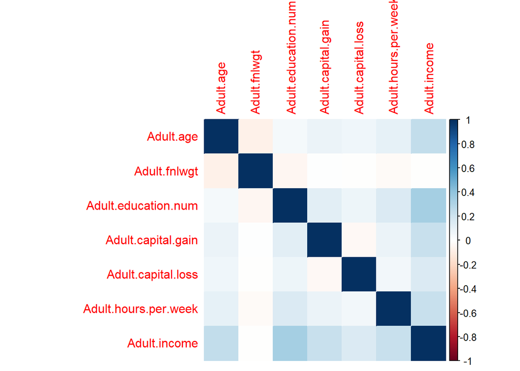

From the above correlation matrix we can say that the variable income is positively correleted to other variables .  
By looking at the colors we can easily know how continous variables are behaving with each other.

## Age Distribution

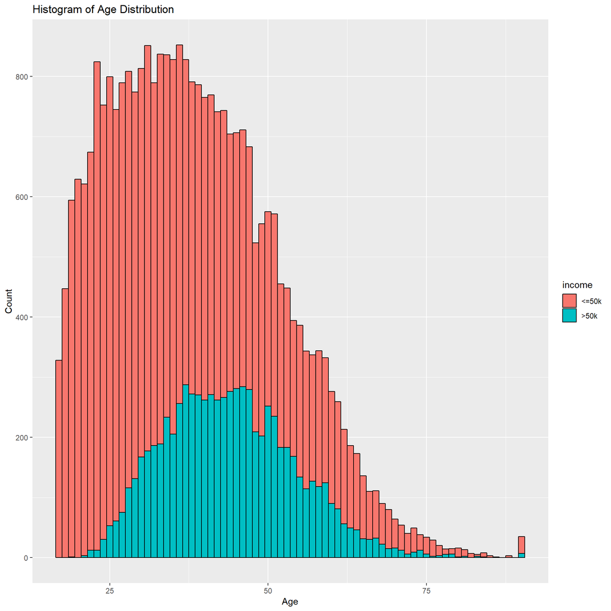

From this plot we can see that the percentage of people who make above 50K peaks are less than who make less than or equal to 50k.  
The age of people who make more than 50k is normally distributted but people who make less than 50k is not normally distributted.

## No. of Adult working in Different Work Class

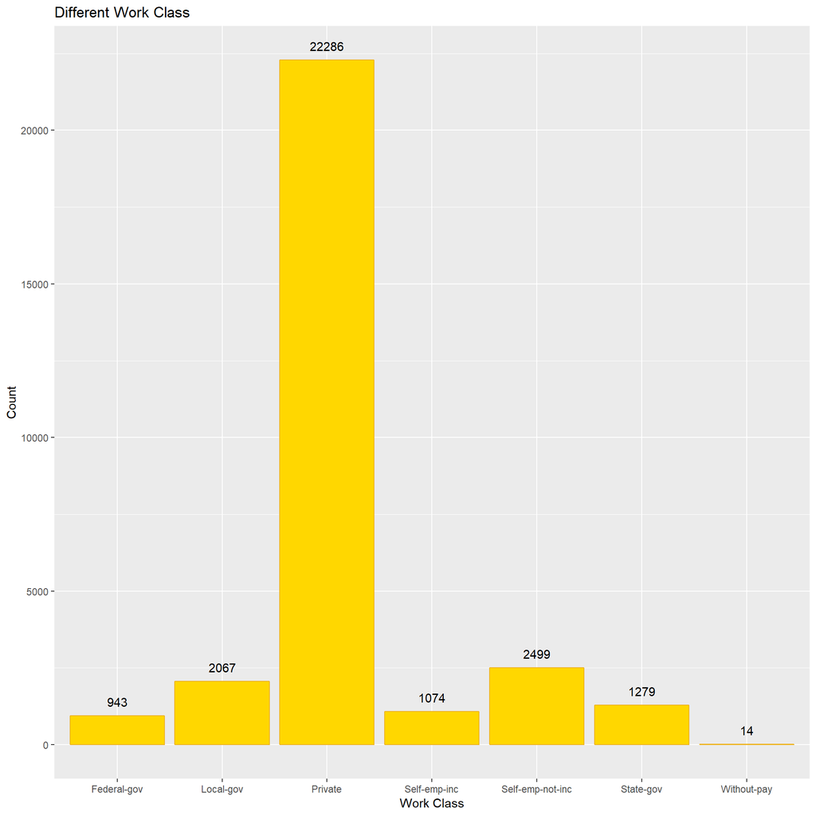

From the above graph we can easily get that most of the adults works in private sector.

## No. of Adult and Education

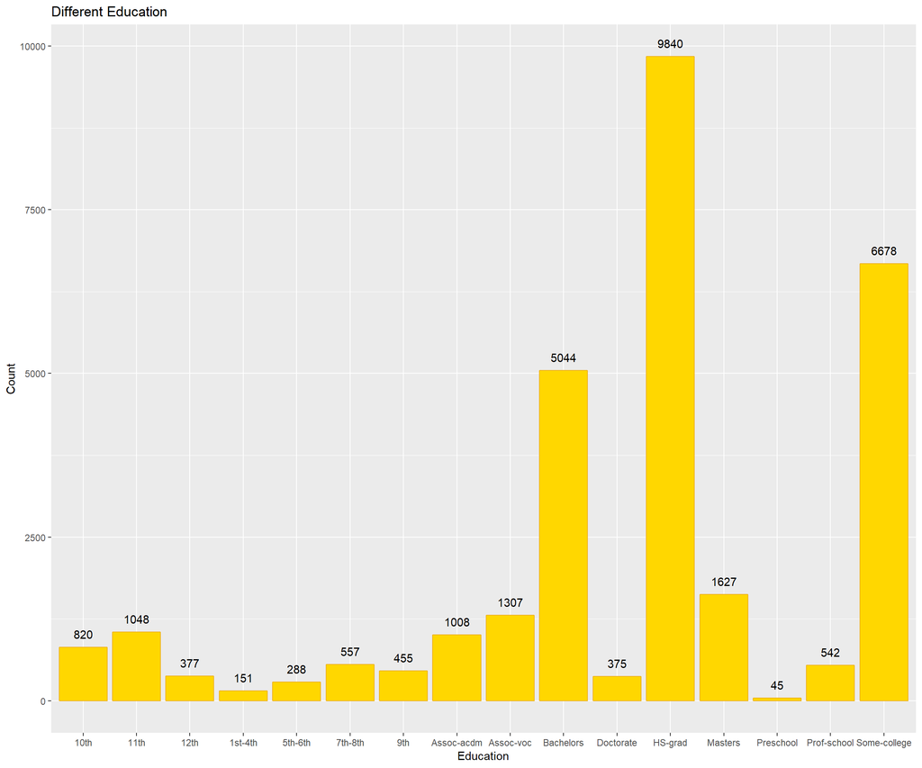

From the above graph we can easily get that most of the adults are educated like they went to HS-grad and some college.

## Marital Status

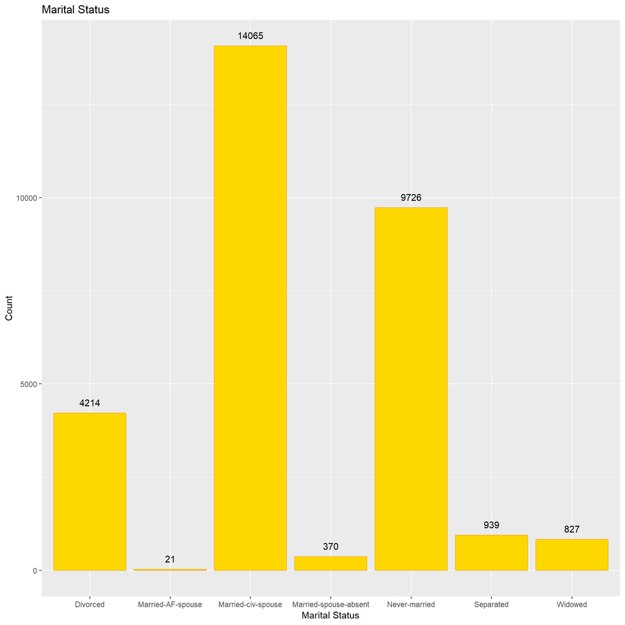

Most of the Adult’s marital status is Married-civ-spouse

## No. of Adult working in Different Occupation

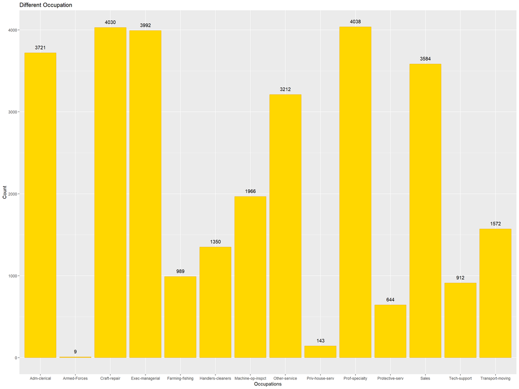

There are only armed force and private house service are the lowest number of adult’s occupation

## Adult Relationship

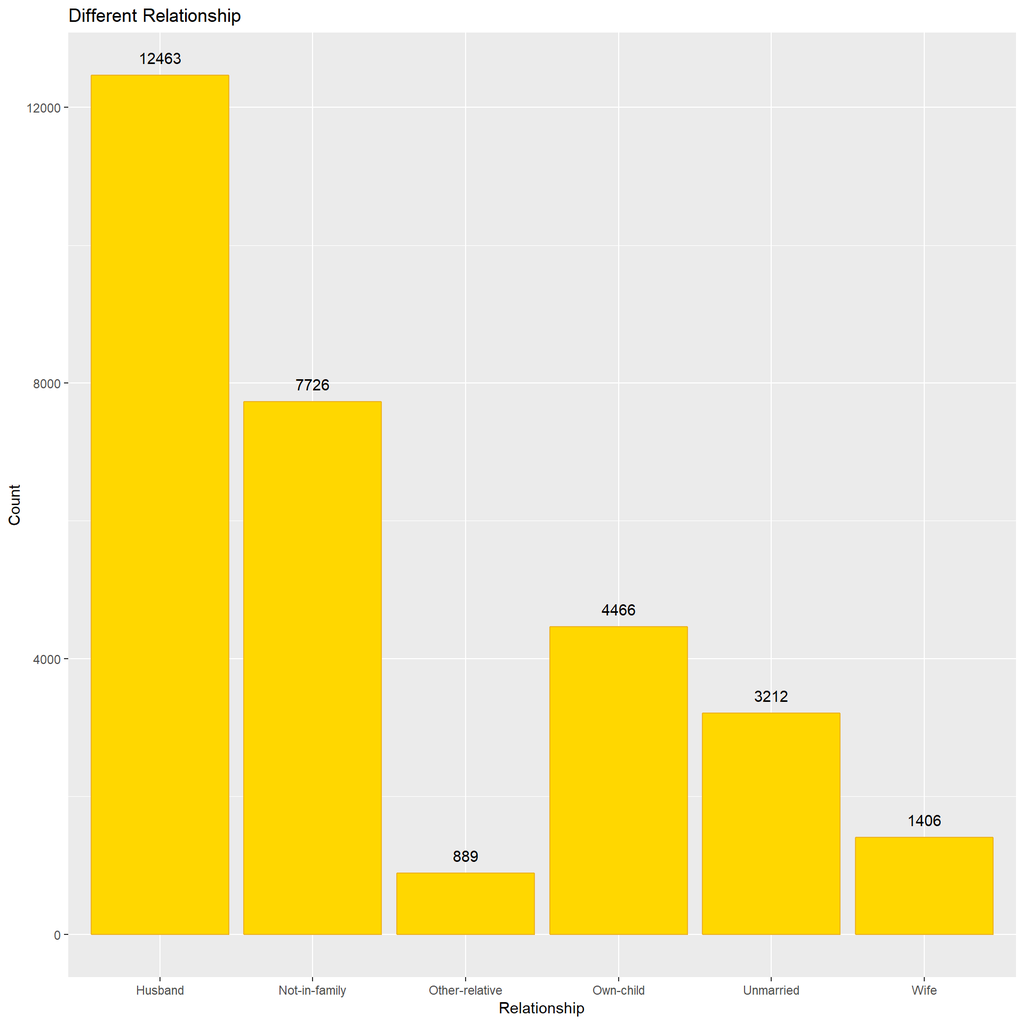

Most of the Adults are husband in our dataset, after that the one which are not in family.

## No. of Adult Race

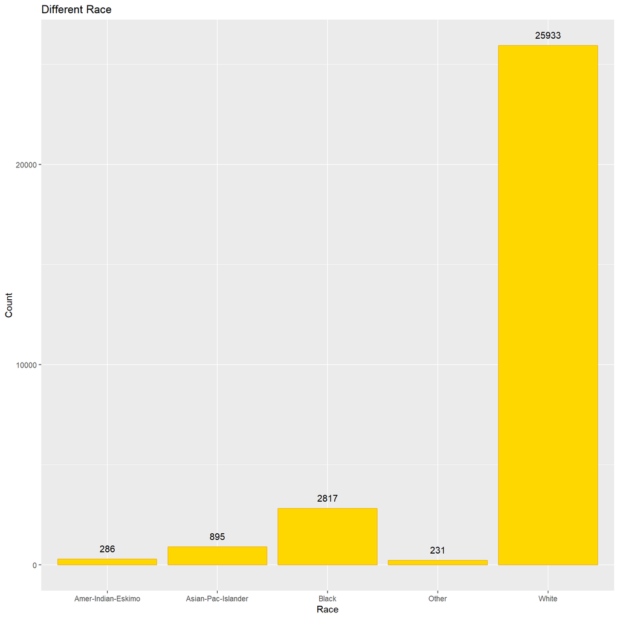

Adults are mostly from White race in our dataset

## Gender

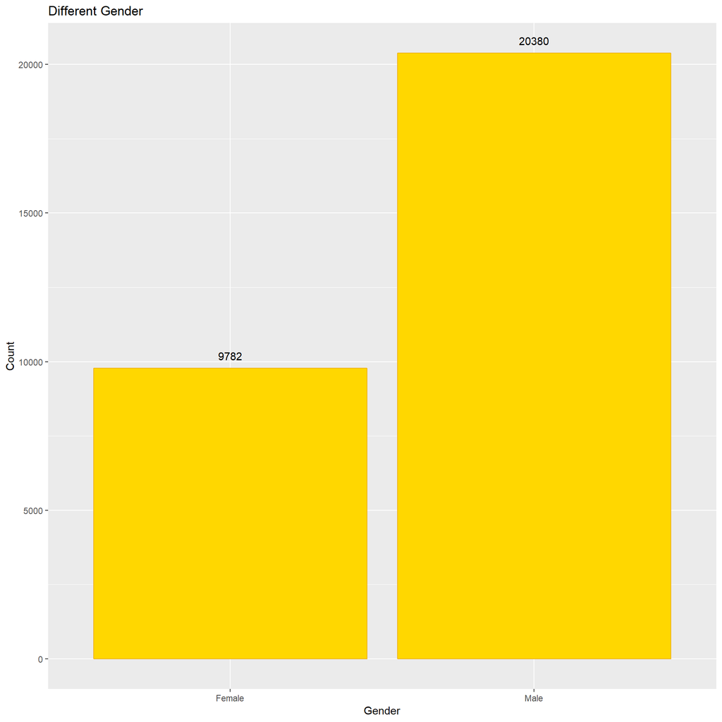

Mostlt Adults are male in our data set

## Impact of Work Class on Income

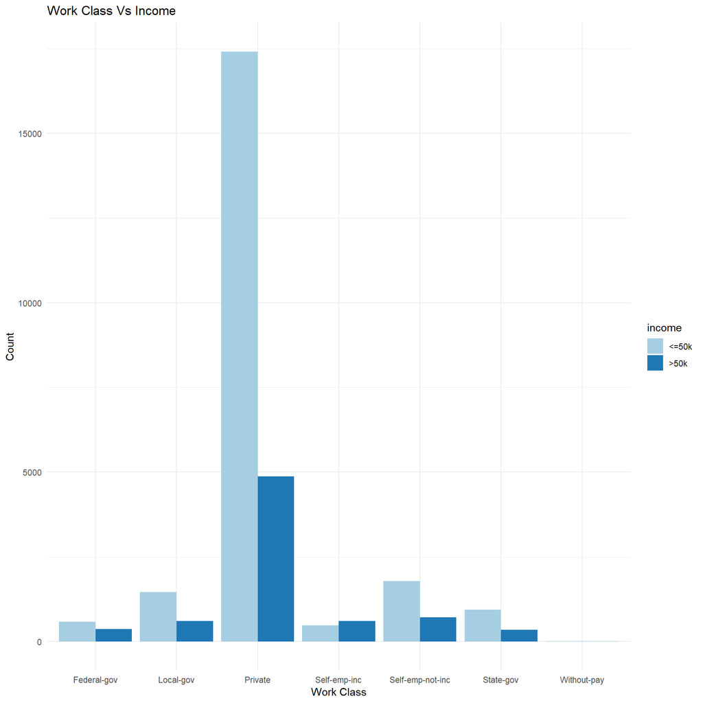

## Impact of Education on Income

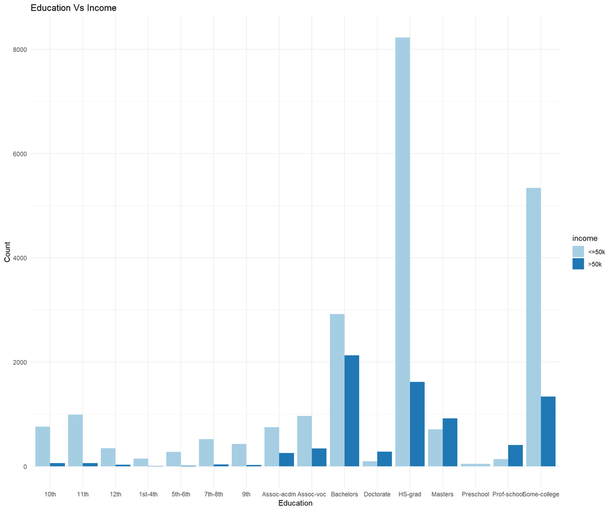

## Impact of Occupation on Income

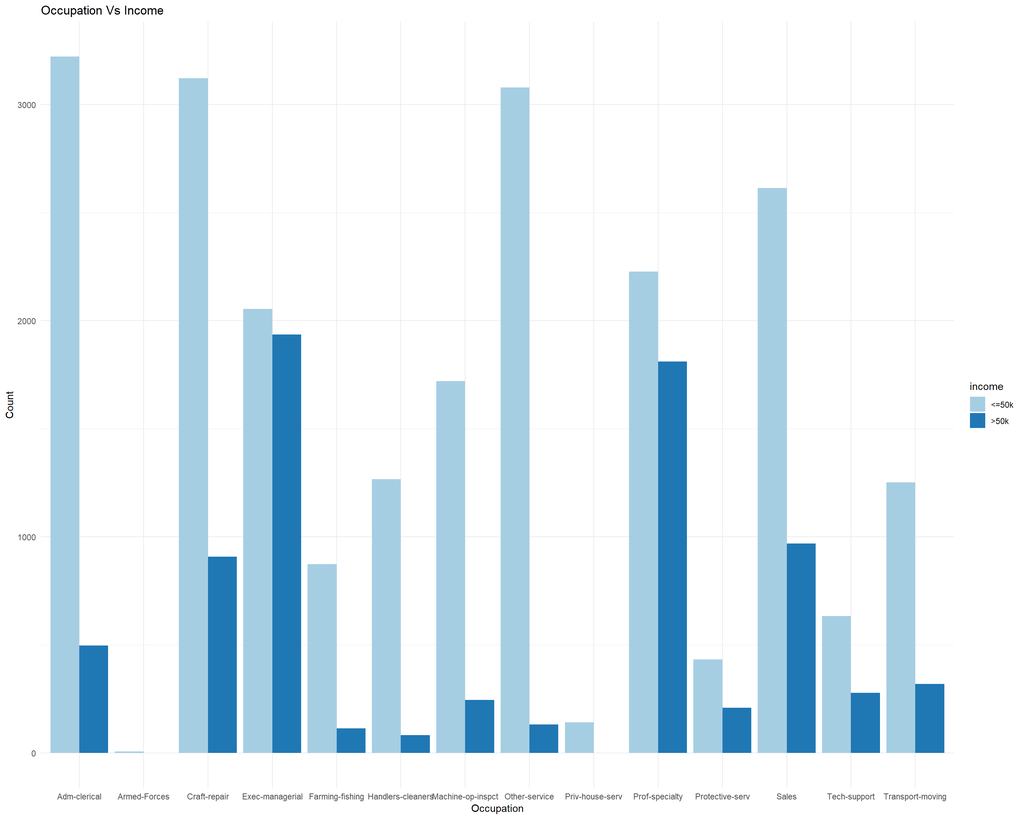

Armed Force is the occupation in which people earn less and it is because less people works there.

## Relationship between Education vs Years of Education

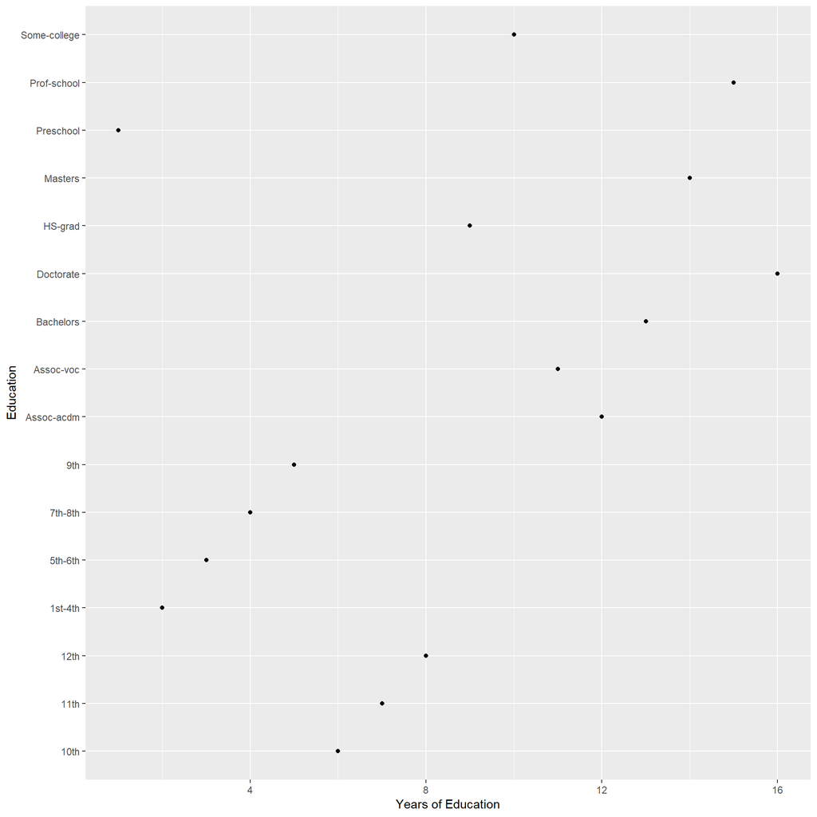

This graphs shows us how many years needed to complete the one of the education category. So we can see thet doctrate need 16 years of education which is maximum in camparison with others.

# Splitting data into training and test datasets.

# Calling KNN function

Using k value as square root of no. of rows in Train Adult **145.5**  
We tried with the value of k = 144,145 and 146 and got the best accuracy with 146.  
So, we are showing its value of k = 146 only because it is will be easy to load the RMD file.

The accuracy of the model: **76.4718976**  
.

```
##        TestIncome
## knn.146 <=50k >50k
##   <=50k  6718 2112
##   >50k      2  153
```

```
## Confusion Matrix and Statistics
##
##        TestIncome
## knn.146 <=50k >50k
##   <=50k  6718 2112
##   >50k      2  153
##
##                Accuracy : 0.7647
##                  95% CI : (0.7558, 0.7735)
##     No Information Rate : 0.7479
##     P-Value [Acc > NIR] : 0.0001155
##
##                   Kappa : 0.0973
##
##  Mcnemar's Test P-Value : < 2.2e-16
##
##             Sensitivity : 0.99970
##             Specificity : 0.06755
##          Pos Pred Value : 0.76082
##          Neg Pred Value : 0.98710
##              Prevalence : 0.74791
##          Detection Rate : 0.74769
##    Detection Prevalence : 0.98275
##       Balanced Accuracy : 0.53363
##
##        'Positive' Class : <=50k
##
```

From the matrix we can know that there are two possible predicted classes: <=50 and >50.  
We are predicting where the adult is earning <=50k or >50k.

**Accuracy:** It will tell how accurate your model is.  
**Sensitivity:** It is also know as True positive rate.  
**Specificity:** It is also know as True Negative rate.  
**Positive Predictive Value (PPV):** when the prediction is positive, how often is it correct.  
**Negative Predictive Value (NPV):** when the prediction is negative, how often is it correct.

```r
#The value  of k from 1 to 20, shows the best value for the accuracy of our model
#Optimization in the code had been done, but were not using those codes here due to the loading speed of RMD file.
```